# Chapter 6: Analysis of longitudinal data

This week data under investigation is longitudinal. Two different data sets will be analyzed.

## Rats

```r
library(dplyr)
```

```r
library(ggplot2)
library(GGally)
library(tidyr)
library(lme4)
RATSL <- read.csv("data/Rats_longitudinal.csv", row.names = 1)
str(RATSL)
```

```
## 'data.frame':    176 obs. of  5 variables:
##  $ ID    : int  1 2 3 4 5 6 7 8 9 10 ...
##  $ Group : int  1 1 1 1 1 1 1 1 2 2 ...
##  $ WD    : chr  "WD1" "WD1" "WD1" "WD1" ...
##  $ Weight: int  240 225 245 260 255 260 275 245 410 405 ...
##  $ Time  : int  1 1 1 1 1 1 1 1 1 1 ...
```

```r
RATSL$ID <- factor(RATSL$ID)
RATSL$Group <- factor(RATSL$Group)
summary(RATSL)
```

```
##        ID      Group       WD                Weight           Time
##  1      : 11   1:88   Length:176         Min.   :225.0   Min.   : 1.00
##  2      : 11   2:44   Class :character   1st Qu.:267.0   1st Qu.:15.00
##  3      : 11   3:44   Mode  :character   Median :344.5   Median :36.00
##  4      : 11                             Mean   :384.5   Mean   :33.55
##  5      : 11                             3rd Qu.:511.2   3rd Qu.:50.00
##  6      : 11                             Max.   :628.0   Max.   :64.00
##  (Other):110
```

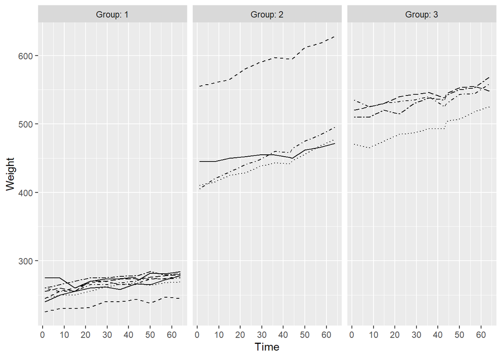

```r
library(ggplot2)
ggplot(RATSL, aes(x = Time, y = Weight, linetype = ID)) +
  geom_line() +
  scale_linetype_manual(values = rep(1:10, times=4)) +
  facet_grid(. ~ Group, labeller = label_both) +
  scale_x_continuous(name = "Time", breaks = seq(0, 60, 10)) +
  scale_y_continuous(name = "Weight") +
  theme(legend.position = "none")
```

First illustration of the data already show the difference between groups. Additionally, on mouse in group 2 is very heavy compared to others.

Next we will have a look of standardized.

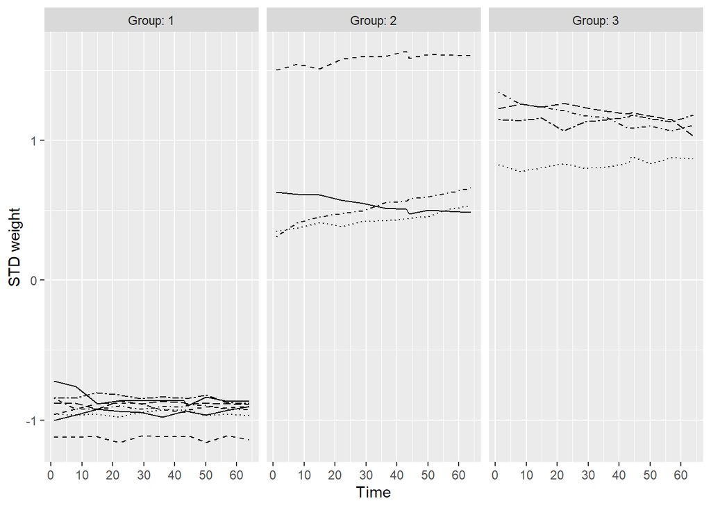

```r
library(dplyr)
RATSL <- RATSL %>%
  group_by(Time) %>%
  mutate(stdweight = (Weight - mean(Weight))/ sd(Weight)) %>%
  ungroup()

ggplot(RATSL, aes(x = Time, y = stdweight, linetype = ID)) +
  geom_line() +
  scale_linetype_manual(values = rep(1:10, times=4)) +
  facet_grid(. ~ Group, labeller = label_both) +
  scale_x_continuous(name = "Time", breaks = seq(0, 60, 10)) +
  scale_y_continuous(name = "STD weight") +
  theme(legend.position = "none")
```

As expected, the growing trend is disappearing.

Next up graphical summary.

```r
n <- RATSL$Time %>% unique() %>% length()
RAT_sum <- RATSL %>%
  group_by(Group, Time) %>%
  summarise( mean = mean(Weight), se = sd(Weight)/sqrt(n) ) %>%
  ungroup()
glimpse(RAT_sum)
```

```
## Rows: 33
## Columns: 4
## $ Group <fct> 1, 1, 1, 1, 1, 1, 1, 1, 1, 1, 1, 2, 2, 2, 2, 2, 2, 2, 2, 2, 2, 2~
## $ Time  <int> 1, 8, 15, 22, 29, 36, 43, 44, 50, 57, 64, 1, 8, 15, 22, 29, 36, ~
## $ mean  <dbl> 250.625, 255.000, 254.375, 261.875, 264.625, 265.000, 267.375, 2~
## $ se    <dbl> 4.589478, 3.947710, 3.460116, 4.100800, 3.333956, 3.552939, 3.30~
```

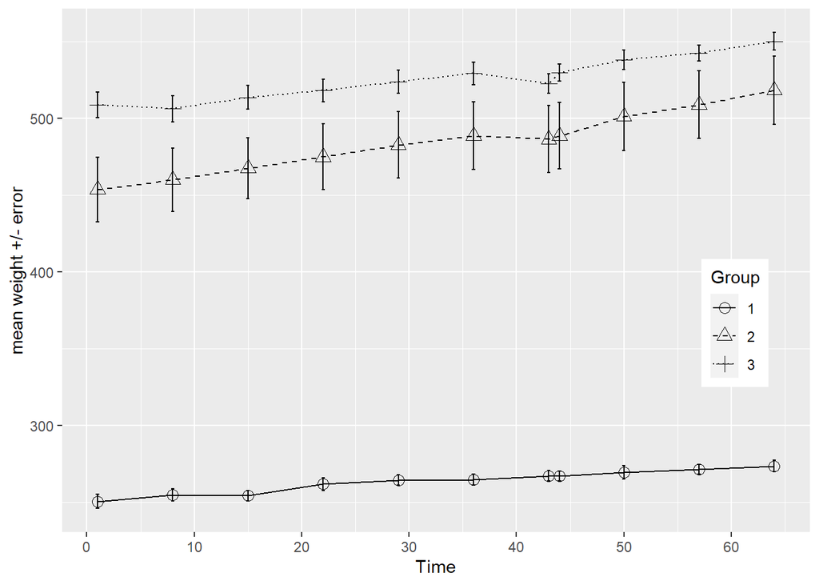

```r
ggplot(RAT_sum, aes(x = Time, y = mean, linetype = Group, shape = Group)) +
  geom_line() +
  scale_linetype_manual(values = c(1,2,3)) +
  geom_point(size=3) +
  scale_shape_manual(values = c(1,2,3)) +
  geom_errorbar(aes(ymin=mean-se, ymax=mean+se, linetype="1"), width=0.3) +
  theme(legend.position = c(0.9,0.4)) +
  scale_x_continuous(name = "Time", breaks = seq(0, 60, 10)) +
  scale_y_continuous(name = "mean weight +/- error")
```

Graph shows clear difference between groups. To conclude this box plot illustration is used.

```r
RAT_sum2 <- RATSL %>%
  filter(Time > 1) %>%
  group_by(Group, ID) %>%
  summarise( mean=mean(Weight) ) %>%
  ungroup()
glimpse(RAT_sum2)
```

```
## Rows: 16
## Columns: 3
## $ Group <fct> 1, 1, 1, 1, 1, 1, 1, 1, 2, 2, 2, 2, 3, 3, 3, 3
## $ ID    <fct> 1, 2, 3, 4, 5, 6, 7, 8, 9, 10, 11, 12, 13, 14, 15, 16
## $ mean  <dbl> 263.2, 238.9, 261.7, 267.2, 270.9, 276.2, 274.6, 267.5, 443.9, 4~
```

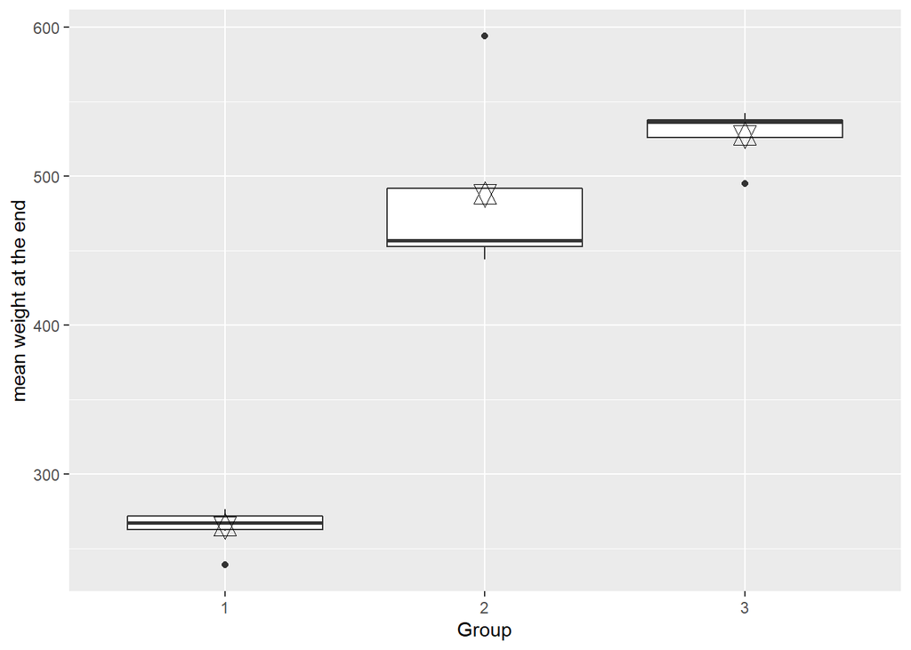

```r
ggplot(RAT_sum2, aes(x = Group, y = mean)) +
  geom_boxplot() +
  stat_summary(fun.y = "mean", geom = "point", shape=11, size=4, fill = "white") +
  scale_y_continuous(name = "mean weight at the end")
```

One of the means in group 2 is much higher compared to outhers so this will be dropped as an outlier.

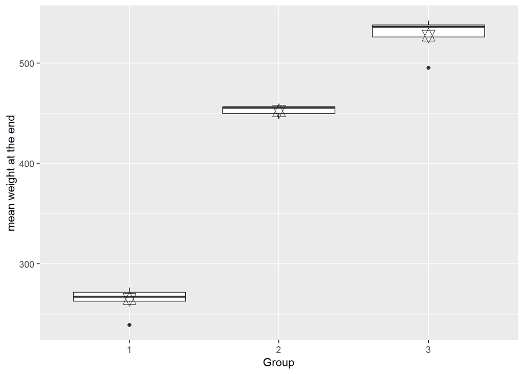

```r
RAT_sum2 <- RAT_sum2 %>% filter(mean < 570)

ggplot(RAT_sum2, aes(x = Group, y = mean)) +
  geom_boxplot() +
  stat_summary(fun.y = "mean", geom = "point", shape=11, size=4, fill = "white") +
  scale_y_continuous(name = "mean weight at the end")
```

And now the means look better! To further conclude the the significance between the groups linear regression analysis will be made.

```r
RATS <- read.table("https://raw.githubusercontent.com/KimmoVehkalahti/MABS/master/Examples/data/rats.txt", sep  ="\t", header = T)
RATS <- RATS[c(-12),]
RAT_sum2 <- RAT_sum2 %>%
  mutate(baseline = RATS$WD1)

mod <- lm(mean ~ baseline + Group, data = RAT_sum2)
anova(mod)
```

```
## Analysis of Variance Table
##
## Response: mean
##           Df Sum Sq Mean Sq   F value    Pr(>F)
## baseline   1 207817  207817 2714.9357 1.601e-14 ***
## Group      2   1483     742    9.6878  0.003748 **
## Residuals 11    842      77
## ---
## Signif. codes:  0 '***' 0.001 '**' 0.01 '*' 0.05 '.' 0.1 ' ' 1
```